# prak5

2023-09-26

#Panggil package

```r
library(ggplot2)
library(tsibble)
library(tseries)
library(MASS)
library(rio)
```

#Input data

```r
data <- import("https://raw.githubusercontent.com/akabanenabaka/mpdw/main/Jumlah%20Perusahaan%20Transaksi%20dan%20Indeks%20Saham%20di%20Bursa%20Efek.csv")
data
```

|  | Period | Yt |
| --- | --- | --- |
| 1 | 1 | 488 |
| 2 | 2 | 488 |
| 3 | 3 | 489 |
| 4 | 4 | 493 |
| 5 | 5 | 494 |
| 6 | 6 | 496 |
| 7 | 7 | 501 |
| 8 | 8 | 501 |
| 9 | 9 | 501 |
| 10 | 10 | 501 |

[output cut: 105 more lines]

#Data time series

```r
dataa <- ts(data$Yt)
dataa
```

```
## Time Series:
## Start = 1
## End = 115
## Frequency = 1
##   [1] 488 488 489 493 494 496 501 501 501 501 501 506 506 506 507 507 510 512
##  [19] 516 517 517 518 518 521 522 524 524 524 525 529 531 531 535 535 535 537
##  [37] 535 535 536 539 543 553 554 555 556 559 560 566 567 568 569 573 581 585
##  [55] 594 598 600 609 615 619 624 625 626 629 630 634 649 647 652 656 661 668
##  [73] 674 680 685 690 691 692 697 700 709 709 708 713 716 720 724 728 729 735
##  [91] 739 740 750 751 755 766 771 774 778 785 787 787 795 809 810 810 820 825
## [109] 835 845 853 858 864 868 876
```

#Plot stasioner

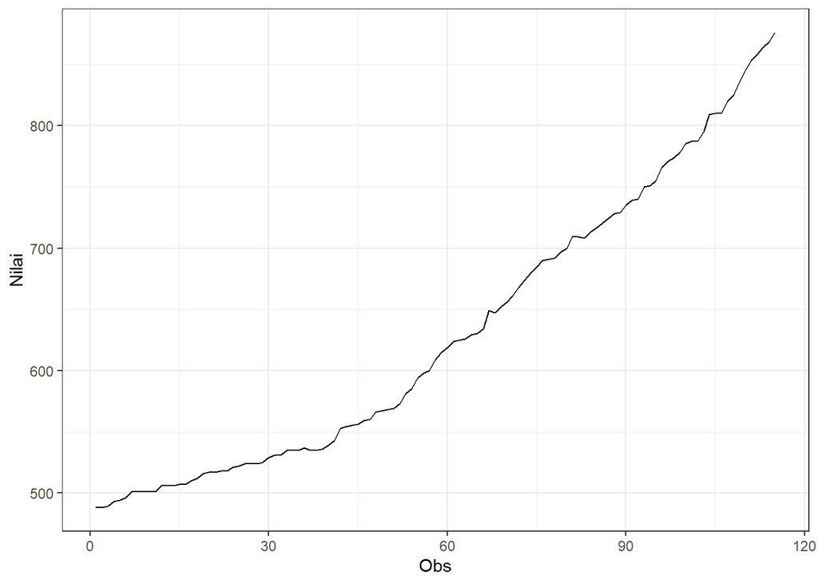

```r
plot_stas2 <- dataa |> as_tsibble() |>
  ggplot(aes(x = index, y = value)) + geom_line() + theme_bw() +
  xlab("Obs") + ylab("Nilai")
plot_stas2
```

```r
mean(dataa)
```

```
## [1] 631.1913
```

Plot deret waktu di atas menunjukkan bahwa data tidak stasioner dalam rataan, ditandai dengan data yang membentuk pola trend dan tidak stasioner dalam ragam, ditandai dengan lebar pita yang tidak sama.

#Plot ACF

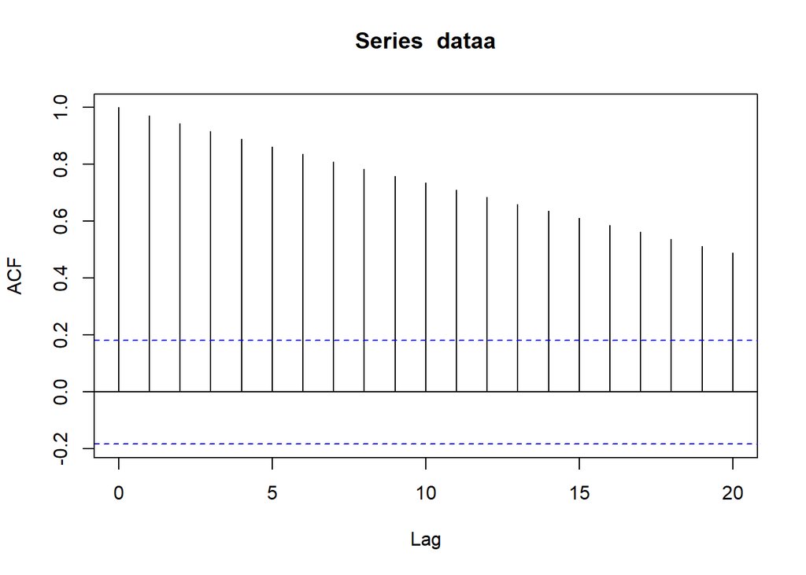

```r
acf(dataa)
```

Berdasarkan plot ACF, terlihat bahwa plot ACF pada data tersebut cenderung *tails off*, namun tidak membentuk gelombang sinus.

#Uji ADF

```r
adf.test(dataa)
```

```
##
##  Augmented Dickey-Fuller Test
##
## data:  dataa
## Dickey-Fuller = -0.30964, Lag order = 4, p-value = 0.9888
## alternative hypothesis: stationary
```

$H_0$ : Data tidak stasioner dalam rataan $H_1$ : Data stasioner dalam rataan

Berdasarkan uji ADF tersebut, didapat *p-value* sebesar 0.9888 yang lebih besar dari taraf nyata 5% sehingga tak tolak $H_0$ dan menandakan bahwa data tidak stasioner dalam rataan. Hal ini sesuai dengan hasil eksplorasi menggunakan plot time series dan plot ACF.

#Plot Box-Cox

```r
index <- seq(1:115)
bc = boxcox(dataa~index, lambda = seq(-2.19,-1.5,by=0.01))
```

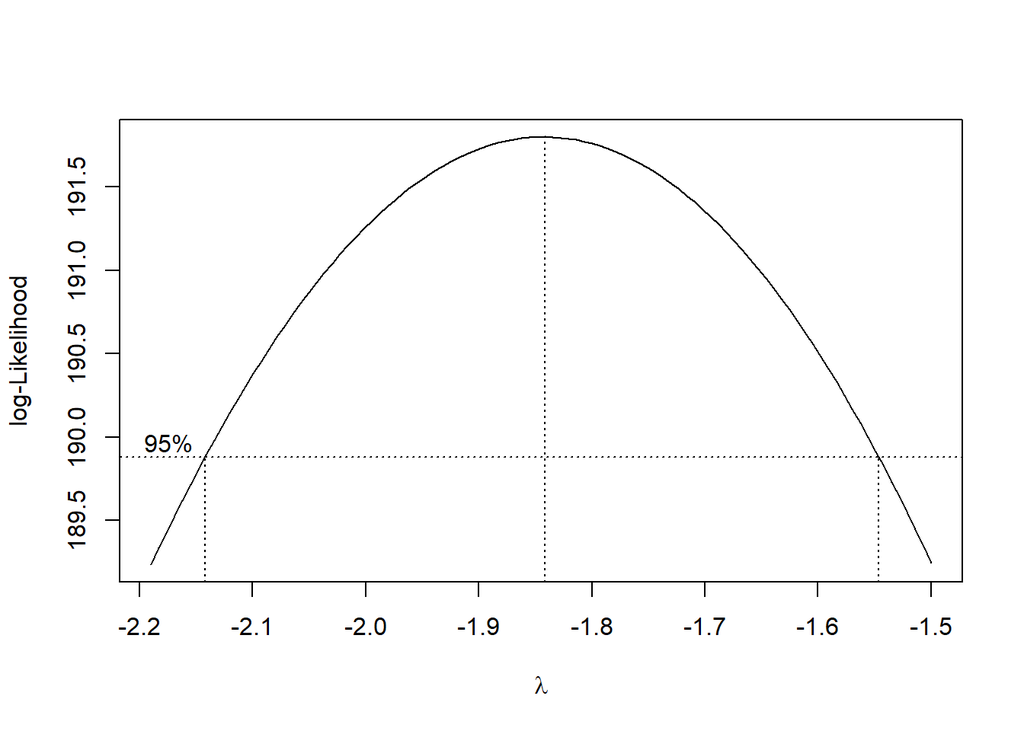

```r
#Nilai Rounded Lambda
lambda <- bc$x[which.max(bc$y)]
lambda
```

```
## [1] -1.841515
```

```r
#SK
bc$x[bc$y > max(bc$y) - 1/2 * qchisq(.95,1)]
```

```
##  [1] -2.141212 -2.134242 -2.127273 -2.120303 -2.113333 -2.106364 -2.099394
##  [8] -2.092424 -2.085455 -2.078485 -2.071515 -2.064545 -2.057576 -2.050606
## [15] -2.043636 -2.036667 -2.029697 -2.022727 -2.015758 -2.008788 -2.001818
## [22] -1.994848 -1.987879 -1.980909 -1.973939 -1.966970 -1.960000 -1.953030
## [29] -1.946061 -1.939091 -1.932121 -1.925152 -1.918182 -1.911212 -1.904242
## [36] -1.897273 -1.890303 -1.883333 -1.876364 -1.869394 -1.862424 -1.855455
## [43] -1.848485 -1.841515 -1.834545 -1.827576 -1.820606 -1.813636 -1.806667
## [50] -1.799697 -1.792727 -1.785758 -1.778788 -1.771818 -1.764848 -1.757879
## [57] -1.750909 -1.743939 -1.736970 -1.730000 -1.723030 -1.716061 -1.709091
## [64] -1.702121 -1.695152 -1.688182 -1.681212 -1.674242 -1.667273 -1.660303
## [71] -1.653333 -1.646364 -1.639394 -1.632424 -1.625455 -1.618485 -1.611515
## [78] -1.604545 -1.597576 -1.590606 -1.583636 -1.576667 -1.569697 -1.562727
## [85] -1.555758 -1.548788
```

Gambar di atas menunjukkan nilai *rounded value* ($\lambda$) optimum sebesar **-1,84** dan pada selang kepercayaan 95% nilai memiliki batas bawah **-2.14** dan batas atas **-1.55**. Selang tersebut tidak memuat nilai satu sehingga dapat dikatakan bahwa data bangkitan tersebut tidak stasioner dalam ragam.

#Partisi data Bagian 1

```r
dataa1 <- dataa[1:58] |> ts()
mean(dataa1)
```

```
## [1] 532.7759
```

```r
var(dataa1)
```

```
## [1] 964.4577
```

#Plot time series

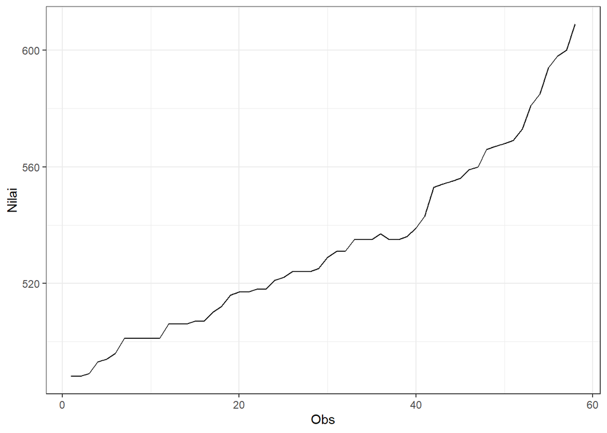

```r
dataa1 |> as_tsibble() |>
  ggplot(aes(x = index, y = value)) +
  geom_line() + theme_bw() +
  xlab("Obs") + ylab("Nilai")
```

Plot deret waktu di atas menunjukkan bahwa data tidak stasioner dalam rataan, ditandai dengan data yang membentuk pola trend dan tidak stasioner dalam ragam, ditandai dengan lebar pita yang tidak sama.

#Plot ACF

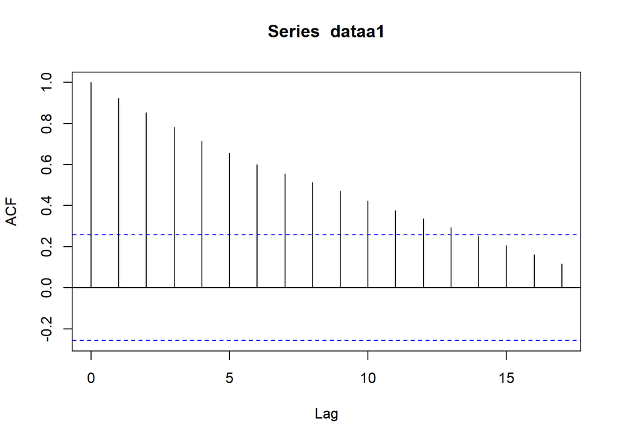

```r
acf(dataa1)
```

Berdasarkan plot ACF, terlihat bahwa plot ACF pada data tersebut cenderung *tails off*, namun tidak membentuk gelombang sinus.

#Uji ADF

```r
adf.test(dataa1)
```

```
##
##  Augmented Dickey-Fuller Test
##
## data:  dataa1
## Dickey-Fuller = 1.3254, Lag order = 3, p-value = 0.99
## alternative hypothesis: stationary
```

$H_0$ : Data tidak stasioner dalam rataan $H_1$ : Data stasioner dalam rataan

#Plot Box-Cox

```r
index <- seq(1:58)
bc = boxcox(dataa1~index, lambda = seq(-7,-4,by=1))
```

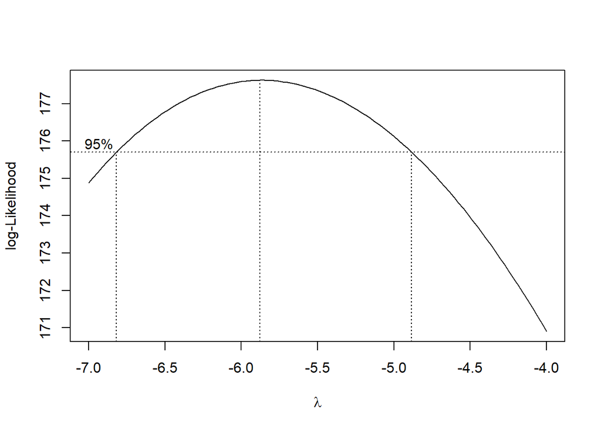

```r
#Nilai Rounded Lambda
lambda <- bc$x[which.max(bc$y)]
lambda
```

```
## [1] -5.878788
```

```r
#SK
bc$x[bc$y > max(bc$y) - 1/2 * qchisq(.95,1)]
```

```
##  [1] -6.787879 -6.757576 -6.727273 -6.696970 -6.666667 -6.636364 -6.606061
##  [8] -6.575758 -6.545455 -6.515152 -6.484848 -6.454545 -6.424242 -6.393939
## [15] -6.363636 -6.333333 -6.303030 -6.272727 -6.242424 -6.212121 -6.181818
## [22] -6.151515 -6.121212 -6.090909 -6.060606 -6.030303 -6.000000 -5.969697
## [29] -5.939394 -5.909091 -5.878788 -5.848485 -5.818182 -5.787879 -5.757576
## [36] -5.727273 -5.696970 -5.666667 -5.636364 -5.606061 -5.575758 -5.545455
## [43] -5.515152 -5.484848 -5.454545 -5.424242 -5.393939 -5.363636 -5.333333
## [50] -5.303030 -5.272727 -5.242424 -5.212121 -5.181818 -5.151515 -5.121212
## [57] -5.090909 -5.060606 -5.030303 -5.000000 -4.969697 -4.939394 -4.909091
```

Gambar di atas menunjukkan nilai *rounded value* ($\lambda$) optimum sebesar **-5.88** dan pada selang kepercayaan 95% nilai memiliki batas bawah **-6.79** dan batas atas **-4.91**. Selang tersebut tidak memuat nilai satu sehingga dapat dikatakan bahwa data bangkitan tersebut tidak stasioner dalam ragam.

#Bagian 2

```r
dataa2 <- dataa[1:115] |> ts()
mean(dataa2)
```

```
## [1] 631.1913
```

```r
var(dataa2)
```

```
## [1] 13149.14
```

#Plot time series

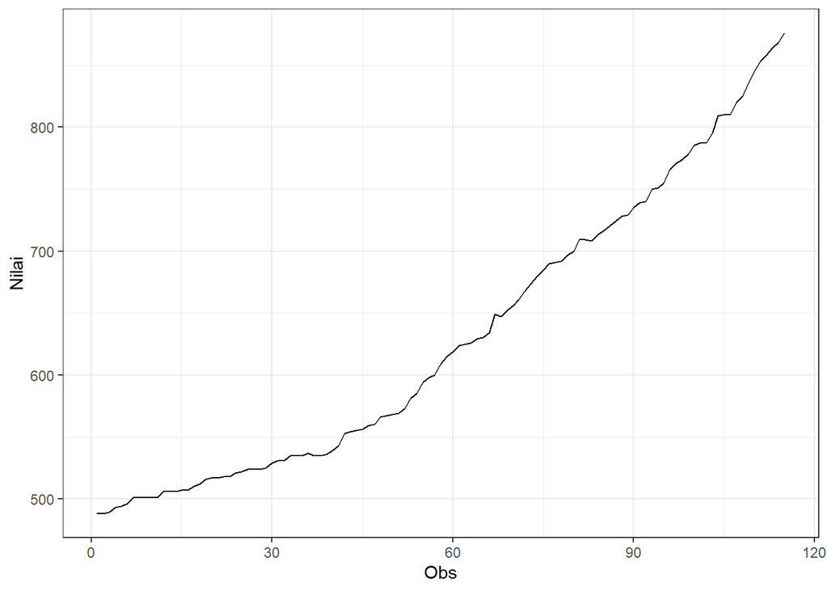

```r
dataa2 |> as_tsibble() |>
  ggplot(aes(x = index, y = value)) +
  geom_line() + theme_bw() +
  xlab("Obs") + ylab("Nilai")
```

Plot deret waktu di atas menunjukkan bahwa data tidak stasioner dalam rataan, ditandai dengan data yang membentuk pola trend dan tidak stasioner dalam ragam, ditandai dengan lebar pita yang tidak sama.

#Plot ACF

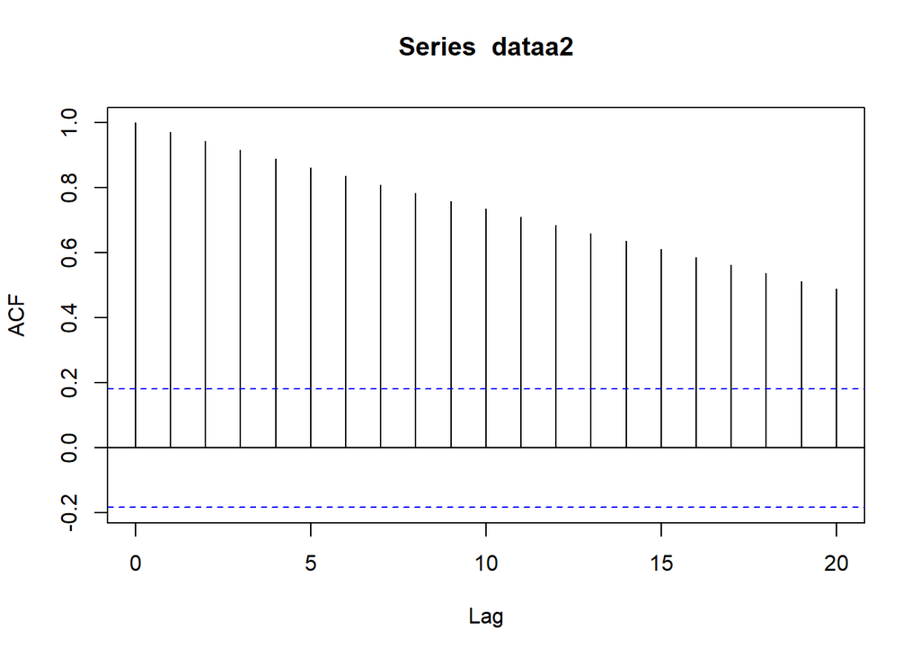

```r
acf(dataa2)
```

Berdasarkan plot ACF, terlihat bahwa plot ACF pada data tersebut cenderung *tails off*, namun tidak membentuk gelombang sinus.

#Uji ADF

```r
adf.test(dataa2)
```

```
##
##  Augmented Dickey-Fuller Test
##
## data:  dataa2
## Dickey-Fuller = -0.30964, Lag order = 4, p-value = 0.9888
## alternative hypothesis: stationary
```

$H_0$ : Data tidak stasioner dalam rataan $H_1$ : Data stasioner dalam rataan

#Plot Box-Cox

```r
index <- seq(1:115)
bc = boxcox(dataa2~index, lambda = seq(-2.5,-0.5,by=1))
```

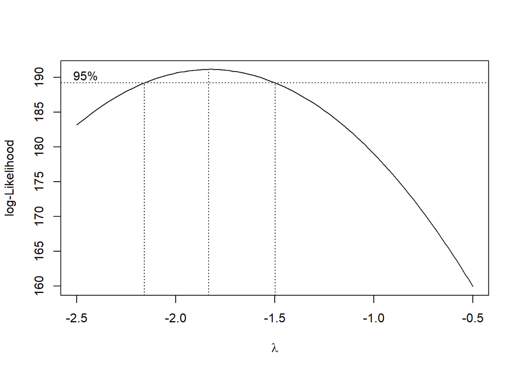

```r
#Nilai Rounded Lambda
lambda <- bc$x[which.max(bc$y)]
lambda
```

```
## [1] -1.833333
```

```r
#SK
bc$x[bc$y > max(bc$y) - 1/2 * qchisq(.95,1)]
```

```
##  [1] -2.156566 -2.136364 -2.116162 -2.095960 -2.075758 -2.055556 -2.035354
##  [8] -2.015152 -1.994949 -1.974747 -1.954545 -1.934343 -1.914141 -1.893939
## [15] -1.873737 -1.853535 -1.833333 -1.813131 -1.792929 -1.772727 -1.752525
## [22] -1.732323 -1.712121 -1.691919 -1.671717 -1.651515 -1.631313 -1.611111
## [29] -1.590909 -1.570707 -1.550505 -1.530303 -1.510101
```

Gambar di atas menunjukkan nilai *rounded value* ($\lambda$) optimum sebesar **-1.83** dan pada selang kepercayaan 95% nilai memiliki batas bawah **-2.16** dan batas atas **-1.51**. Selang tersebut tidak memuat nilai satu sehingga dapat dikatakan bahwa data bangkitan tersebut tidak stasioner dalam ragam.